# Taller N1

Johan Ayala y Daniel Mayor

30/10/2021

## Librerias

Estas son las librerias que seran usadas para efectos de este taller, cada una de las cuales nos servira para realizar las diferentes actividades propuestas.

```r
library("tidyverse")
library("esquisse")
library("knitr")
library("magrittr")
library("saber")
library(corrplot)
library(RColorBrewer)
library(Hmisc)
library(car)
library(psych)
library(ggplot2)
library(scales)
library(dplyr)
```

El examen Saber 11 es una evaluación estandarizada realizada semestralmente por el Icfes que tiene como objetivos: seleccionar estudiantes para la educación superior, monitorear la calidad de la formación que ofrecen los establecimientos de educación media y producir información para la estimación del valor agregado de la educación superior

### Muestra de la base de datos

```r
data("SB11_20061")
datos = SB11_20061
head(datos)
```

```
## # A tibble: 6 x 86
##   FTP_CONSECUTIVO PERIODO ESTU_TIPODOCUMENTO ESTU_PAIS_RESIDE ESTU_GENERO
##   <chr>             <int> <chr>              <chr>            <chr>
## 1 SB1120061001602   20061 T                  CO               F
## 2 SB1120061001603   20061 C                  CO               M
## 3 SB1120061001604   20061 T                  CO               M
## 4 SB1120061001605   20061 T                  CO               F
## 5 SB1120061001606   20061 T                  CO               F
## 6 SB1120061001607   20061 T                  CO               F
## # ... with 81 more variables: ESTU_NACIMIENTO_DIA <int>,
## #   ESTU_NACIMIENTO_MES <int>, ESTU_NACIMIENTO_ANNO <int>, ESTU_EDAD <int>,
## #   ESTU_DISC_BAJAVISION <chr>, ESTU_DISC_SORDOCEGUERA <chr>,
## #   ESTU_DISC_COGNITIVA <chr>, ESTU_DISC_INVIDENTE <chr>,
## #   ESTU_DISC_MOTRIZ <chr>, ESTU_DISC_SORDOINTERPRETE <chr>,
## #   ESTU_DISC_SORDONOINTERPRETE <chr>, ESTU_CODIGO_RESIDE_MCPIO <int>,
## #   ESTU_RESIDE_MPIO_PRESENTACION <chr>, ...
```

## Características generales

1. La siguiente base de datos consta de 86 columnas:

```r
p = ncol(datos)
print(p)
```

```
## [1] 86
```

2. La base de datos de la prueba saber pro 11 contiene 42 variables categóricas

```r
a=sapply(X = datos, FUN = class)
f=0
g=0
for (e in 1:length(a)) { if (a[e]=='integer'|a[e]=='numeric'){f=f+1} else {g=g+1}}
g
```

```
## [1] 42
```

3. Considerando como numericas aquellas variables que cumplan la condicion de ser Integer o que sean numeric, tenemos que existen 44 variables numericas

```r
f
```

```
## [1] 44
```

4. La base de datos de la prubea saber pro contiene 86 variables y 61.069 registros

```r
p = nrow(datos)
print(p)
```

```
## [1] 61069
```

## Particulares

5. En este caso dos estudiantes obtieron un puntaje de 101 en fisica, lo cual nos dice que tenemos dos departamentos, en este caso es el de Bogotá y el del valle

```r
d=datos %>% select(ESTU_RESIDE_DEPT_PRESENTACION, FISICA_PUNT) %>%
  arrange(desc(FISICA_PUNT))
head(d,2)
```

```
## # A tibble: 2 x 2
##   ESTU_RESIDE_DEPT_PRESENTACION FISICA_PUNT
##   <chr>                               <dbl>
## 1 "BOGOTÃ\u0081"                       101.
## 2 "VALLE"                              101.
```

```r
d=datos %>% select(ESTU_RESIDE_MPIO_PRESENTACION, FISICA_PUNT) %>%
  arrange(desc(FISICA_PUNT))
tail(d,5)
```

```
## # A tibble: 5 x 2
##   ESTU_RESIDE_MPIO_PRESENTACION FISICA_PUNT
##   <chr>                               <dbl>
## 1 CALI                                    0
## 2 TUMACO                                  0
## 3 YOPAL                                   0
## 4 TORO                                    0
## 5 CALI                                    0
```

7. El departamento de la persona con mayor puntuación en filosofía es Bogotá

```r
d=datos %>% select(ESTU_RESIDE_DEPT_PRESENTACION, FILOSOFIA_PUNT) %>%
  arrange(desc(FILOSOFIA_PUNT))
head(d,1)
```

```
## # A tibble: 1 x 2
##   ESTU_RESIDE_DEPT_PRESENTACION FILOSOFIA_PUNT
##   <chr>                                  <dbl>
## 1 "BOGOTÃ\u0081"                          104.
```

```r
d=datos %>% select(ESTU_RESIDE_MPIO_PRESENTACION, FILOSOFIA_PUNT) %>%
  arrange(desc(FILOSOFIA_PUNT))
tail(d,5)
```

```
## # A tibble: 5 x 2
##   ESTU_RESIDE_MPIO_PRESENTACION FILOSOFIA_PUNT
##   <chr>                                  <dbl>
## 1 CALI                                       0
## 2 CALI                                       0
## 3 CALI                                       0
## 4 SANTAFÃ‰ DE ANTIOQUIA                      0
## 5 CALI                                       0
```

## Estadísticos univariados

9. Como existen valores nulos, en este caso son solo 2, se reemplazan con 0 y se realiza el cálculo de la media, dandonos que para la puntuación de matemáticas la media es de 50.76 puntos.

```r
datos <- mutate_at(datos, c("MATEMATICAS_PUNT"), ~replace(., is.na(.), 0))
mean(datos$MATEMATICAS_PUNT)
```

```
## [1] 50.76583
```

10. El cálculo de la desviación estandar de la puntuación de matemáticas es 9.642533

```r
sd(datos$MATEMATICAS_PUNT)
```

```
## [1] 9.642533
```

```r
datos <- mutate_at(datos, c("ECON_SN_COMPUTADOR"), ~replace(., is.na(.), 0))
d=table(datos$ECON_SN_COMPUTADOR)
(1-d[1]/dim(datos)[1])*100
```

```
##       0
## 2.56595
```

12. El % de de estudiantes que trabaja es del 1.3%

```r
datos <- mutate_at(datos, c("ESTU_TRABAJA"), ~replace(., is.na(.), 0))
d=table(datos$ESTU_TRABAJA)
(1-d[1]/dim(datos)[1])*100
```

```
##        0
## 1.313269
```

13. El 59.12% de los estudiantes que presentaron el Icfes de ese año son de colegios oficiales

```r
d=table(datos$COLE_NATURALEZA)
(d[2]/dim(datos)[1])*100
```

```
##        O
## 59.12984
```

```r
p10.value = quantile(x = datos$ESTU_EDAD, probs = 0.10)
p10.value
```

```
## 10%
##  15
```

15. La edad del 15% menor es de 16 años

```r
p15.value = quantile(x = datos$ESTU_EDAD, probs = 0.15)
p15.value
```

```
## 15%
##  16
```

16. Los 5 municipios con más estudiantes son:

```r
datos <- mutate_at(datos, c("ESTU_RESIDE_MPIO_PRESENTACION"), ~replace(., is.na(.), 0))

tail(sort(table(datos$ESTU_RESIDE_MPIO_PRESENTACION)),5)
```

```
##
## BUENAVENTURA      PALMIRA BOGOTÃ\201 D.C.        PASTO         CALI
##         2263         2855         4421         4991        19545
```

## Graficos univariados

17. El siguiente histograma es de la variable puntación del lenguaje.

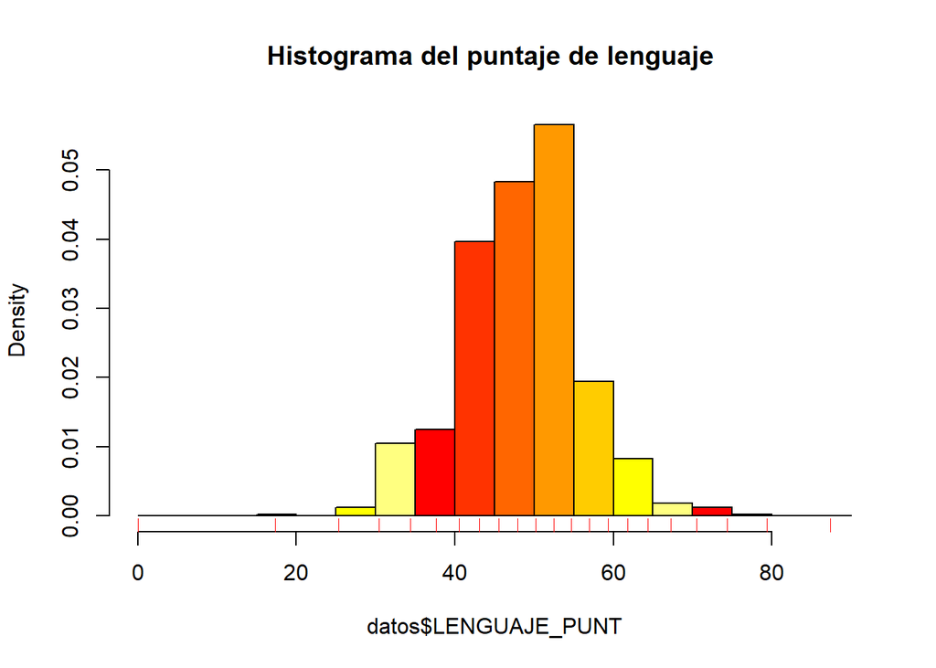

```r
hist(datos$LENGUAJE_PUNT, main = "Histograma del puntaje de lenguaje ", freq = FALSE,
     col = heat.colors(7)); rug(datos$LENGUAJE_PUNT, col = "red")
```

18. El siguiente diagrama de barras es el conteo de los diferentes estratos de los estudiantes que realizaron la prueba del saber pro, elimiando aquellos que no tenian estrato social.

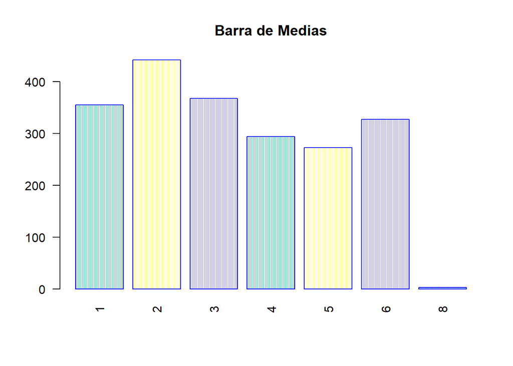

```r
datos <- mutate_at(datos, c("ESTU_ESTRATO"), ~replace(., is.na(.), 0))
a=table(datos%>%select(ESTU_ESTRATO)%>%filter(ESTU_ESTRATO >0))
barplot(a, col = brewer.pal(3, "Set3"), main = "Barra de Medias",
        density = 60, angle = 90, border = "blue", lwd = 1, las = 2)
```

19. El siguiente es un Box-plot de las edades de los estudiantes que realizaron el examen.

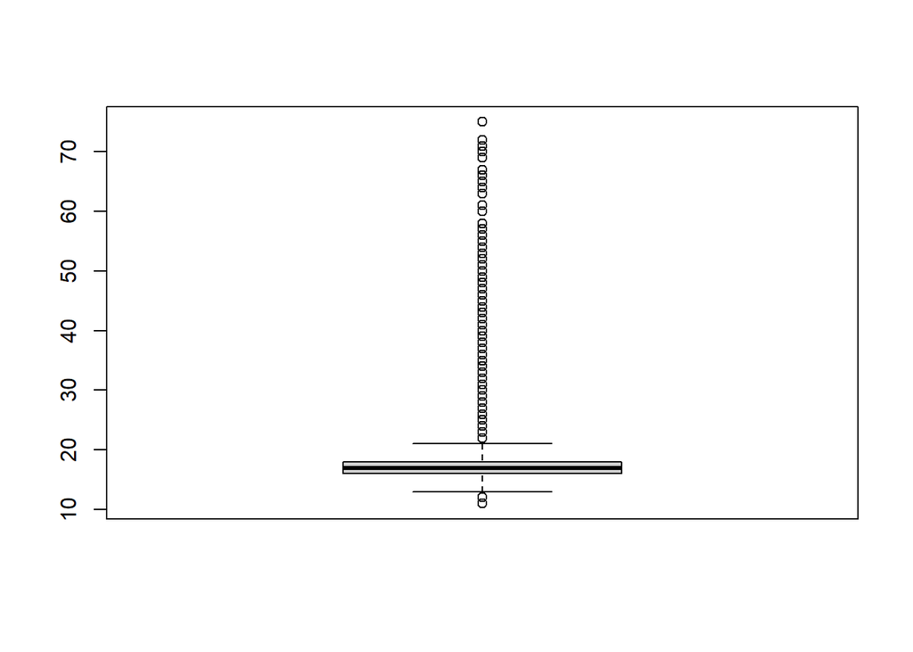

```r
boxplot(datos$ESTU_EDAD)
```

## Correlaciones

20. El siguiente grafico muestra las principales correlaciones de las variables de algunos de los puntajes de la prueba.

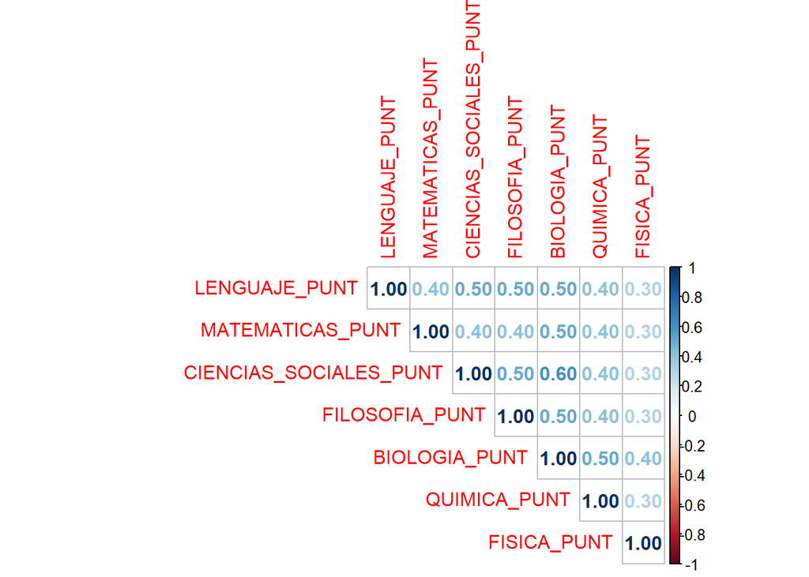

```r
as<-datos%>%select(LENGUAJE_PUNT,MATEMATICAS_PUNT,CIENCIAS_SOCIALES_PUNT,FILOSOFIA_PUNT,BIOLOGIA_PUNT,
                     QUIMICA_PUNT,FISICA_PUNT)
correlacion<-round(cor(as), 1)

corrplot(correlacion, method="number", type="upper")
```

Del anterior grafico podemos decir las siguientes cosas: la primera es que todos los puntajes tienen una correlacion positiva no tan significativa pero la hay, lo segundo es que existe una correlacion de 0.6 entre ciencias sociales y biologia, lo tercero es que la variable lenguaje tiene una correlación de 0.5 con varias de las ciencias que podriamos catalogar como humanas.

21. El siguiente grafico muestra la interración de las variables de algunos de los puntajes de la prueba.

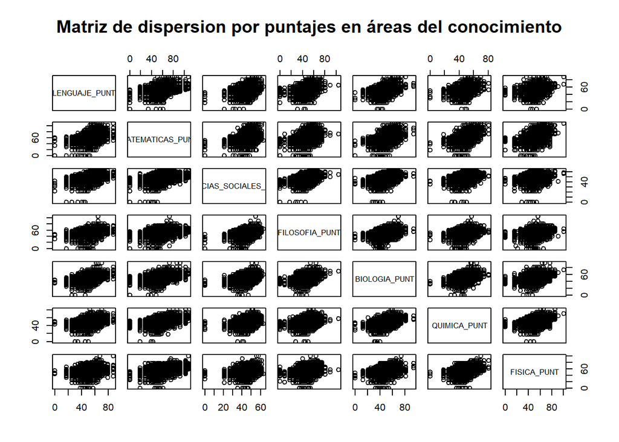

```r
pairs(LENGUAJE_PUNT ~ MATEMATICAS_PUNT + CIENCIAS_SOCIALES_PUNT + FILOSOFIA_PUNT+BIOLOGIA_PUNT+
        QUIMICA_PUNT+FISICA_PUNT,
      data=datos,
      main="Matriz de dispersion por puntajes en áreas del conocimiento")
```